# Stroop_Effect_Analysis

Ekta Raj

September 5, 2017

# Stroop Effect

The **Stroop Test**, a psychological phenomenon, (and the resulting **Stroop Effect**, which is the name given to the experience of an individual who takes the test) shows that our brains process seemingly conflicting information differently than they process more straightforward information.

In other words, when we see the word ‘red’ written in the color red, we process the color of the word more quickly than if the word ‘red’ were written in green and we were expected to just name the color rather than the word. Does that make sense? Essentially, the Stroop Effect studies how interference can affect the way our brains process information and complete tasks.

The task has two conditions:

1. A congruent words condition.
2. An incongruent words condition.

In the congruent words condition, the words being displayed are color words whose names match the colors in which they are printed.

In the incongruent words condition, the words displayed are color words whose names do not match the colors in which they are printed.

In each case, we measure the time it takes to name the ink colors in equally-sized lists.

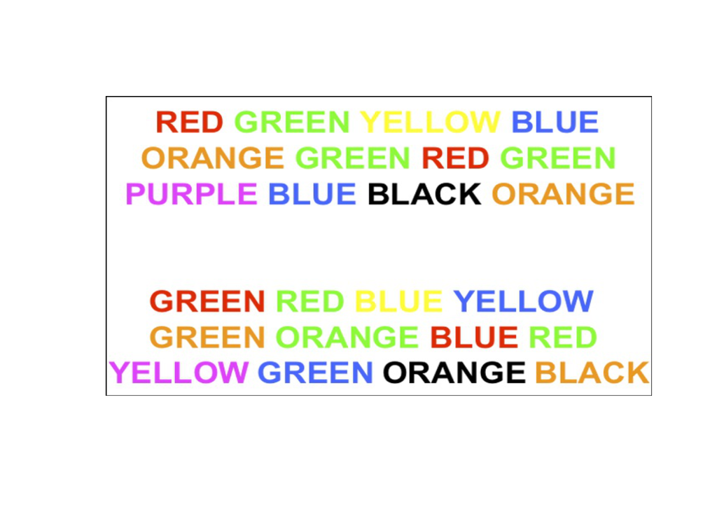

## Analysis of Stroop Effect

In this analysis, I will apply descriptive statistics and inferential statistics to scruitnize the Stroop Effect.

The dataset I used, contains 24 oberservations of the time taken in both congruent and incongruent conditions.

This is how the dataset looks like.

```
## # A tibble: 24 x 3
##    Congruent Incongruent Difference
##        <dbl>       <dbl>      <dbl>
##  1    12.079      19.278      7.199
##  2    16.791      18.741      1.950
##  3     9.564      21.214     11.650
##  4     8.630      15.687      7.057
##  5    14.669      22.803      8.134
##  6    12.238      20.878      8.640
##  7    14.692      24.572      9.880
##  8     8.987      17.394      8.407
##  9     9.401      20.762     11.361
## 10    14.480      26.282     11.802
## # ... with 14 more rows
```

# Data distribution

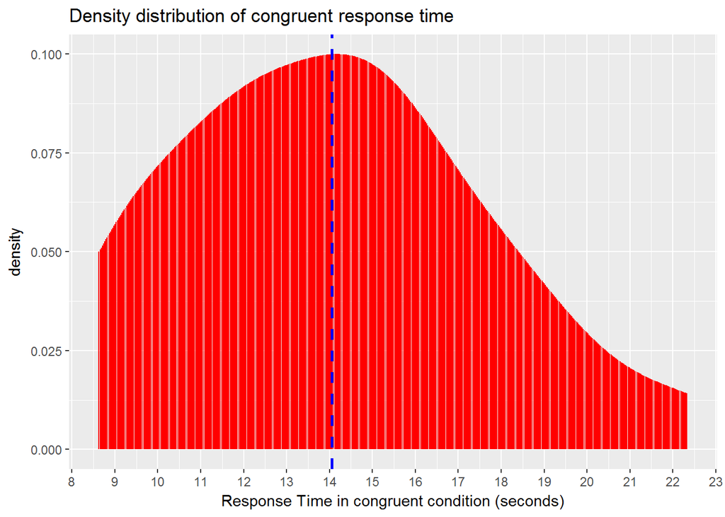

- The above plot shows the density distribution of time taken to say out **congruent words**. It is a normal distribution.
- The minimum time taken is around 8.5 seconds while highest is around 22 seconds.
- Most dense is between 13.5 to 14.5
- The blue vertical line represent mean value.

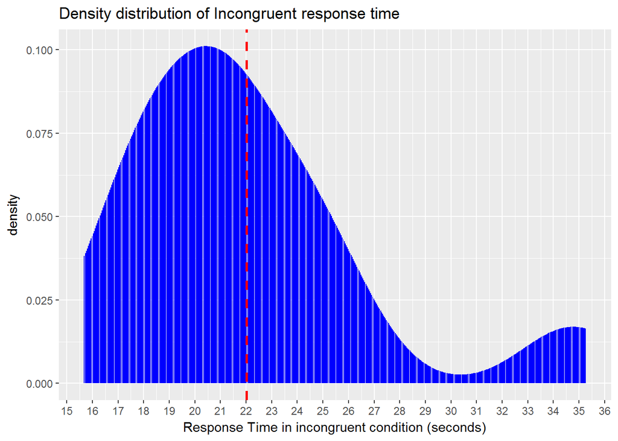

- The above plot shows the density distribution of time taken to say out **incongruent words**. It is a normal distribution.
- The minimum time taken is around 15.6 seconds while highest is around 35 seconds.
- Most dense is between 20 to 21 seconds.
- The density near 33 t0 35 seconds is very low.
- The red vertical line represents mean value

## Diving into investigation

Our goal is to determine whether the mean difference between congruent and incongruent condition is significantly different from 0.

Let’s understand some symbols used in this analysis:

*µ<sub>1</sub>* : Population mean response time in congruent condition

*µ<sub>2</sub>* : Population mean response time in incongruent condition

*µ<sub>D</sub>* : Population mean difference of response time.

*x̅<sub>1</sub>* : Sample mean response time in congruent condition

*x̅<sub>2</sub>* : Sample mean response time in incongruent conditions

*x̅<sub>D</sub>* : Sample mean difference of reponse time

*H<sub>0</sub>* : Null hypothese

*H<sub>a</sub>* : Alternative hypothesis

*$\alpha$* : Level of likelihood/significance

*p-value* : Probability of null hypotheses to be true.

*t<sub>critical</sub>*: A critical value is the point (or points) on the scale of the test statistic beyond which we reject the null hypothesis, and is derived from the level of significance α of the test.

*t<sub>statistics</sub>* : The t-value measures the size of the difference relative to the variation in your sample data.

*CI* : A range of values so defined that there is a specified probability that the value of a parameter(mean) lies within it.

*d* : Cohen’s d is an appropriate effect size for the comparison between two means.

*r<sup>2</sup>* : Correlation measure

## Independent variable and dependent variable.

1. Each participant is an **independent variable**. The reponse time of one participant does not get affected by response time of other participant.
2. The reponse time of each participant is a **dependent variable**. It depends on:
- Congruent and incongruent conditions.
- Age, because young children who recognize the color name but can not read the words are likely to perform better in both the conditions in comparison with other participants.
- Does the task well understood?.
- Any kind of distraction while taking the test.

## Set of hypotheses for this task.

In this task we will have a set of two hypotheses:

- Null Hypotheses - H<sub>0</sub>
- Alternative Hypotheses - H<sub>a</sub>

H<sub>0</sub> : The mean difference of congruent time and incongruent time is 0.

H<sub>a</sub> : The mean difference of congruent time and incongruent time is not 0.

Mathematically we express it as:

> **H<sub>0</sub> : µ<sub>2</sub> - µ<sub>1</sub> = 0**

> **H<sub>a</sub> : µ<sub>2</sub> - µ<sub>1</sub> ≠ 0**

## Type of statistical test used.

The most appropriate statistical test in this task is *dependent sample t-test* since one sample goes through two tests in two different conditions.

t-test is very useful to compare the mean of two samples. Also, t-test is useful when poplation parameters are unknown and sample size is less than 30. Our dataset meets these conditions.

It is a two-tailed t-test since we assume that µ<sub>2</sub> ≠ µ<sub>1</sub>.

## Descriptive Statistics

```
##    Congruent      Incongruent      Difference
##  Min.   : 8.63   Min.   :15.69   Min.   : 1.950
##  1st Qu.:11.90   1st Qu.:18.72   1st Qu.: 3.646
##  Median :14.36   Median :21.02   Median : 7.667
##  Mean   :14.05   Mean   :22.02   Mean   : 7.965
##  3rd Qu.:16.20   3rd Qu.:24.05   3rd Qu.:10.258
##  Max.   :22.33   Max.   :35.26   Max.   :21.919
```

**The mean of time in congruent condition and incongruent condition:**

> - x̅<sub>1</sub> = 14.05
> - x̅<sub>2</sub> = 22.02

**The mean differnce of time in congruent condition and incongruent condition:**

> - x̅<sub>D</sub> = x̅<sub>2</sub> - x̅<sub>1</sub> = 7.97

**Standard deviation of Difference of time:**

> - S<sub>D</sub> = 4.87

**Standard error of the difference between two dependent samples:**

> - S<sub>err</sub> = 0.99

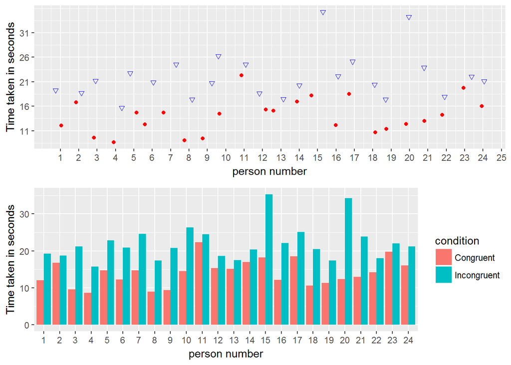

- Both the plots above, clearly shows that time taken in congruent word condition is less than that in incongruent condition.

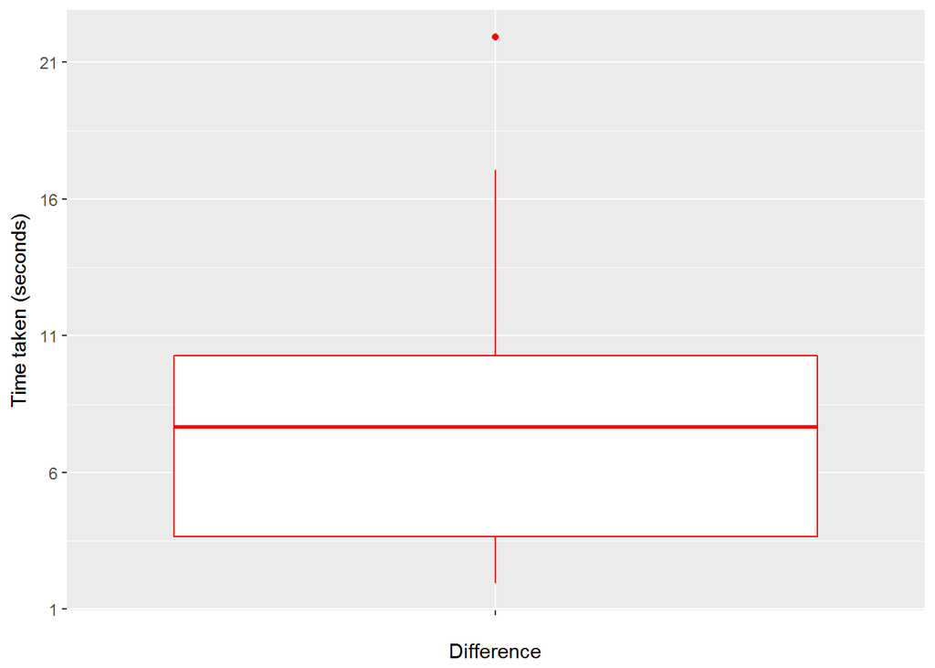

- The boxplot shows that the median of difference of timing is around 7.6.
- Mean difference for 50% participants is less than 7.6 while othe 50% is above it.
- There is also an outlier, where the difference is very high. It seems the participant took too much time to understand the phenomenon.

## Inferential Statistics.

One-sample t-test has been performed on the dataset.

> - Level of significance *$\alpha$* = 0.05
> - Since size of sample is 24, *degree of freedom (df) = 23*
> - t<sub>critical</sub> = ±2.069

**t-statistics**

T is simply the calculated difference represented in units of standard error. The greater the magnitude of T (it can be either positive or negative), the greater the evidence against the null hypothesis that there is no significant difference. The closer T is to 0, the more likely there isn’t a significant difference.

> - t(23) = 8.02, p < 0.025, two-tailed*

Since value of t<sub>statistics</sub> > t<sub>critical</sub>:

t<sub>statistics</sub> falls in the critical region where we reject the null hypotheses.

**Confidence interval**

Confidence level = 95% Confidence interval on mean difference:

> - 95% of CI = (5.91, 10.02)

Thus, there is a 95% probability that mean difference of time in both the condtion would fall in the in range of (5.91 to 10.02).

**Correlation measure**

*r<sup>2</sup>* is a correlation measure that find the proportion or percentage of variation in one variable that is related to another variable (one variable is known).

> - r<sup>2</sup> is = 0.736 ~ 73.6%

It is pretty high.This means that we can tell that there is 73.6% variation in one variable(either congruent or incongruent) knowing the one of them.

**Cohen’s d**

Cohen’s d is an effect size used to indicate the standardised difference between two means. The mean difference is broken into number of standard deviations, which indicates that how far are the means, in the standard deviation units.

> - d = 1.64

## Results of Analysis:

- We reject the null hypotheses H<sub>0</sub>. The probability (p-value) of the mean differnce to be equal to zero is very low.
- Alternative hypotheses is TRUE. Thus mean difference of both the conditions is not equal to zero.
- Thus diffence between time taken to name the color of the ink in congruent and incongruent conditions is statistically signifcant.
- Since the mean diffence was positive (x̅<sub>2</sub> - x̅~), incongruent word condition takes more time to be processed by brain as compared to that with congruent word condition.
- Since I had also taken this psychological test, I observed that it was significantly difficult, hence time taking, to say out words that conflict with its ink.
- Thus the result of the hypotheses test meets my expectation.
- We are 95% confident that average difference in the time taken in both the conditions will be between 5.91 and 10.02.
- Correlation meaure is 73.6%.
- Standardized mean difference is 1.64.

## Conclusion

Thus we conclude that our hypotheses was wrong. Human brain tend to take more time when processing conflicting information thus the mean difference of time taken in reciting congruent and incogruent list of words, has to be greater than 0.

## Reason behind the result

According to me human brain can’t help but read. We are habitual readers. We encounter and comprehend words on such a persistent basis that the reading occurs almost effortlessly, whereas declaration of a color requires more cognitive effort. When there is a conflict between these two sources of information, our cognitive load is increased, and our brains have to work harder to resolve the required difference. Performing these tasks ultimately slows down our responses, and makes the task take longer.

## Similar kind of task

I suggest a similar kind of phenomenon called ceiling effect.

**Ceiling effect** in treatment, is pain relief by some kinds of analgesic drugs, which have no further effect on pain above a particular dosage level.

We can take test samples and observe the difference and ultimately at what point the drug stops having any effect on the pain.